# Lab 4

Morris Chi

2025-09-19

# Task 1

```r
getwd()
```

```
## [1] "C:/Users/kat10/OneDrive/Desktop/RProjects/RPackages/MATH4753MORRISCHIFALL/lab4"
```

# Task 2

```r
spruce.df = read.csv("SPRUCE.csv")
tail(spruce.df)
```

```
##    BHDiameter Height
## 31       17.7   19.9
## 32       20.7   19.4
## 33       21.0   20.4
## 34       13.3   15.5
## 35       15.9   17.6
## 36       22.9   19.2
```

# Task 3

What shape is seen? TRIANGLE

P-Value? 0.29

Null Hypothesis? Fails to reject Null Hypothesis

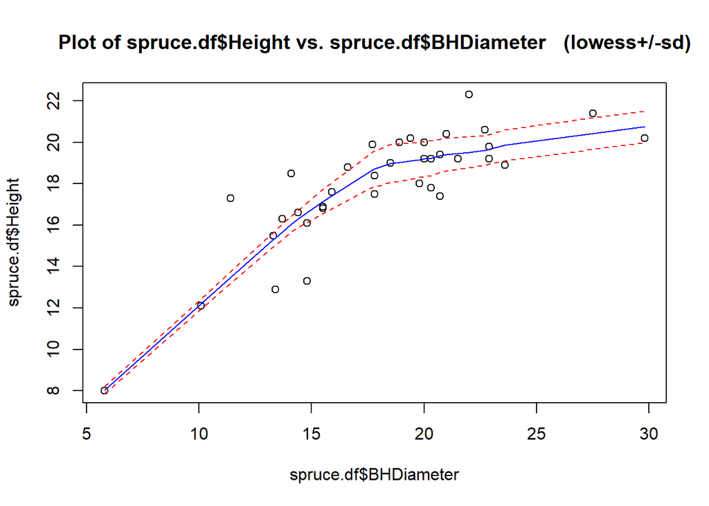

```r
library(s20x)
trendscatter(spruce.df$Height ~ spruce.df$BHDiameter, f = 0.5)
```

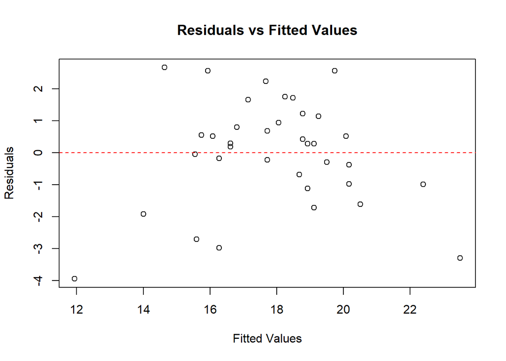

```r
spruce.lm = with(spruce.df ,lm(Height~BHDiameter))

height.res <- residuals(spruce.lm)
height.fit <- fitted(spruce.lm)

plot(height.fit, height.res, main = "Residuals vs Fitted Values",
     xlab = "Fitted Values", ylab = "Residuals")
abline(h = 0, col = "red", lty = 2)
```

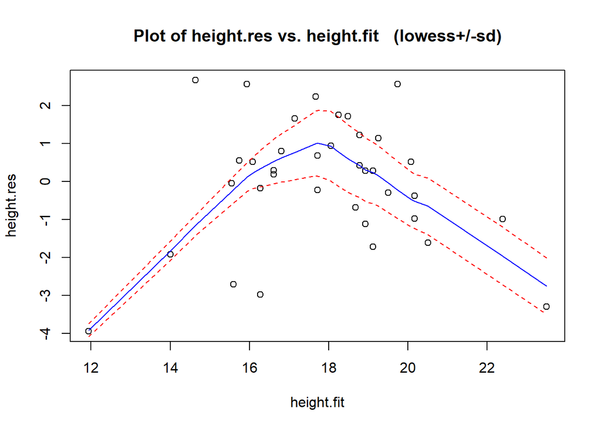

```r
trendscatter(height.res ~ height.fit, f = 0.5)
```

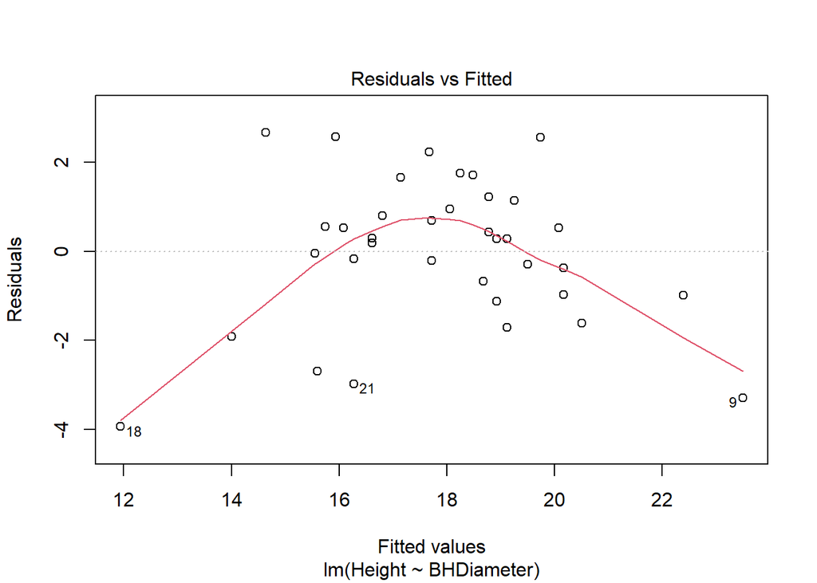

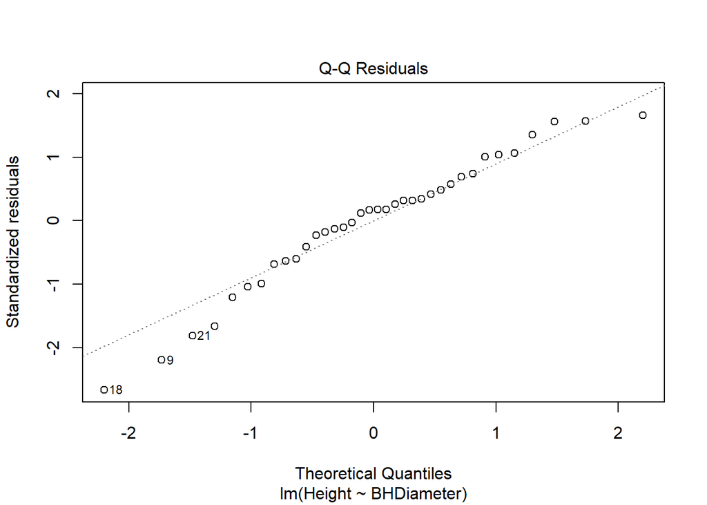

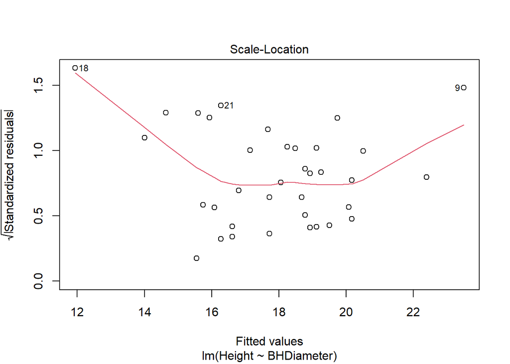

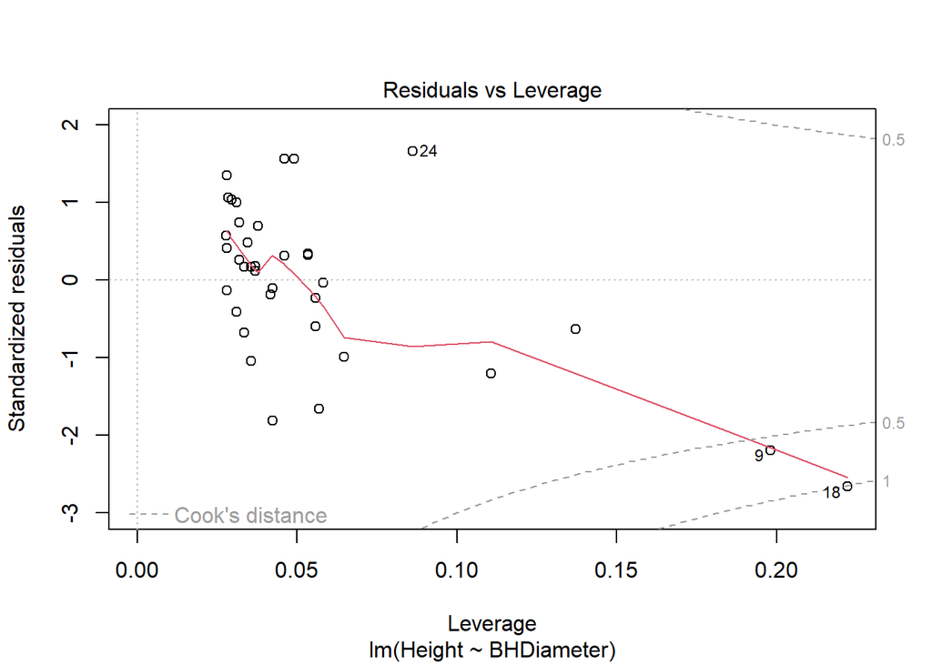

```r
plot(spruce.lm)
```

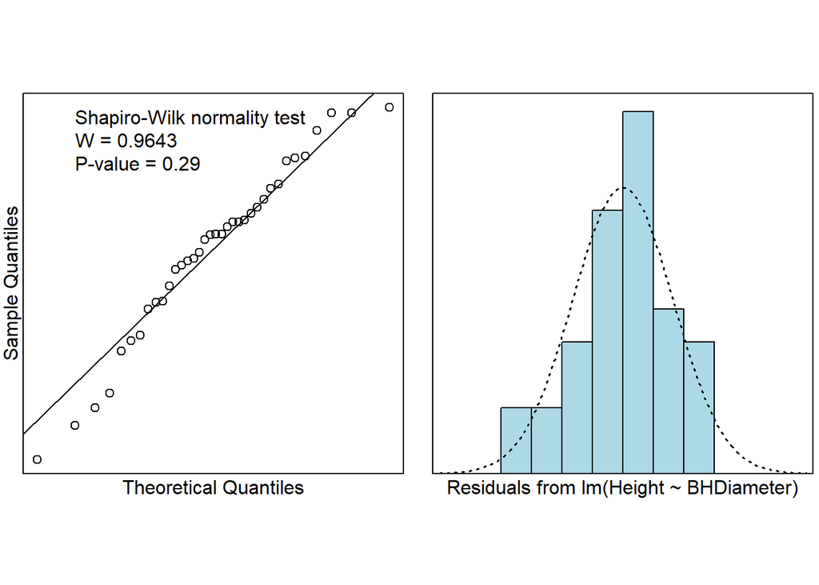

```r
normcheck(spruce.lm, shapiro.wilk = TRUE)
```

# Task 4

P-Value: 0.684

I conclude that it fails to reject the Null Hypothesis, and that the residuals seem to be normal. That means that the quadratic model is valid for this data set

[figure not shown]

```r
quad.lm <- lm(Height ~ BHDiameter + I(BHDiameter^2), data = spruce.df)
plot(spruce.df$BHDiameter, spruce.df$Height, main="Height vs BHDiameter with Quadratic Fit",
     xlab="Breast Height Diameter (cm)", ylab="Height (m)", pch=16)
# Add the quadratic curve
lines(spruce.df$BHDiameter, predict(quad.lm), col="blue", lwd=2)
```

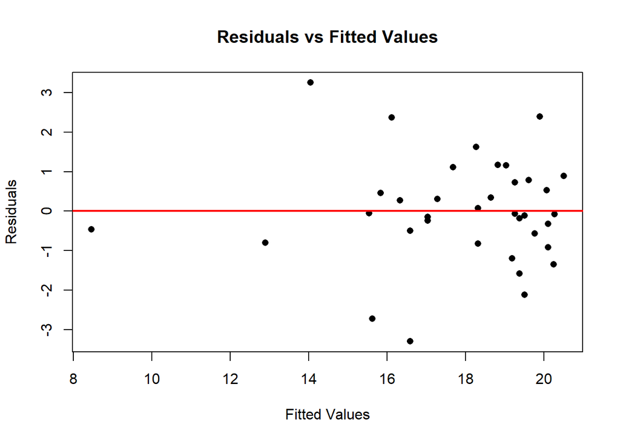

```r
quad.fit <- fitted(quad.lm)

plot(quad.fit, residuals(quad.lm), main="Residuals vs Fitted Values",
     xlab="Fitted Values", ylab="Residuals", pch=16)
abline(h = 0, col = "red", lwd = 2)
```

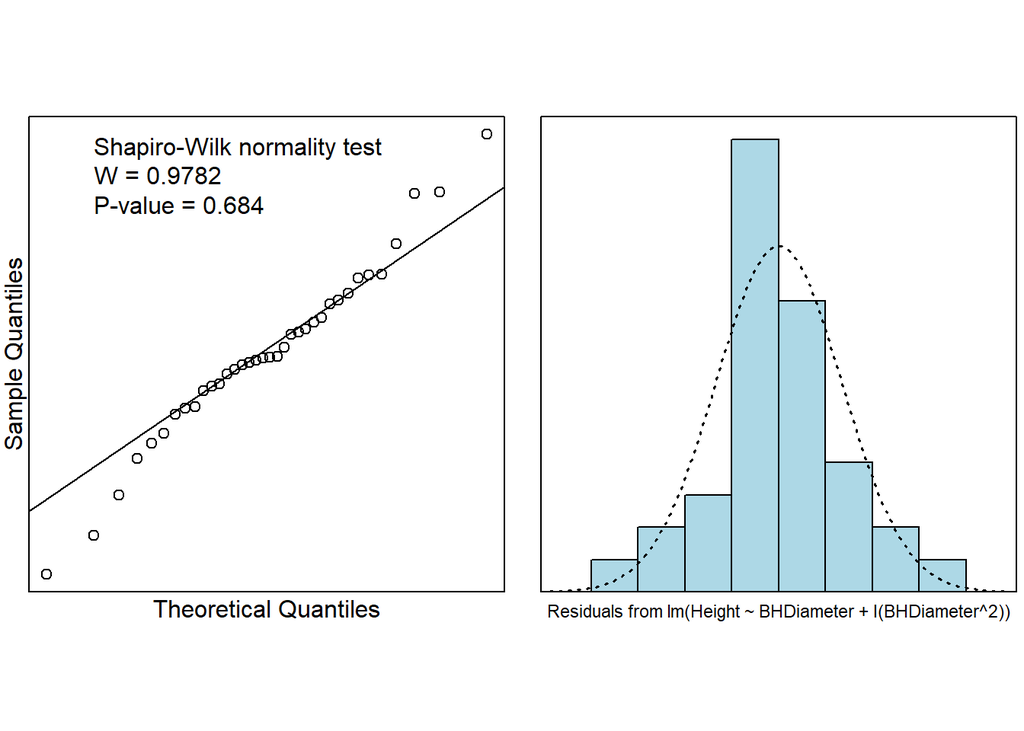

```r
library(s20x)
normcheck(quad.lm, shapiro.wilk = TRUE)
```

# Task 5

Call: lm(formula = Height ~ BHDiameter + I(BHDiameter^2), data = spruce.df)

Residuals: Min 1Q Median 3Q Max -3.2966 -0.6245 -0.0707 0.7442 3.2541

Residual standard error: 1.382 on 33 degrees of freedom Multiple R-squared: 0.7741, Adjusted R-squared: 0.7604 F-statistic: 56.55 on 2 and 33 DF, p-value: 2.182e-11

B(0): 0.860896

B(1): 1.469592

B(2): -0.027457

Interval Estimates:

Predictions at 15, 18, 20cm: 16.72690, 18.41740, 19.26984

R^2 value: 0.7741

Multiple R^2 means how well the variation is explained by the BHDiameter^2, the BHDiameter, and the Intercept

The quadratic model best explains the variability in the height

Anova: Model 1: Height ~ BHDiameter Model 2: Height ~ BHDiameter + I(BHDiameter^2) Res.Df RSS Df Sum of Sq F Pr(>F)  
1 34 95.703  
2 33 63.007 1 32.696 17.125 0.0002269 ***

Since the P-value is less than 0.05, it rejects the Null Hypothesis, which means that the quadratic model is better for the data set than the straight line

TSS: 278.9475

RSS: 63.00683

MSS: 215.9407

MSS/TSS: 0.7741266

```r
summary(quad.lm)
```

```
##
## Call:
## lm(formula = Height ~ BHDiameter + I(BHDiameter^2), data = spruce.df)
##
## Residuals:
##     Min      1Q  Median      3Q     Max
## -3.2966 -0.6245 -0.0707  0.7442  3.2541
##
## Coefficients:
##                  Estimate Std. Error t value Pr(>|t|)
## (Intercept)      0.860896   2.205022   0.390 0.698731
## BHDiameter       1.469592   0.243786   6.028 8.88e-07 ***
## I(BHDiameter^2) -0.027457   0.006635  -4.138 0.000227 ***
## ---
## Signif. codes:  0 '***' 0.001 '**' 0.01 '*' 0.05 '.' 0.1 ' ' 1
##
## Residual standard error: 1.382 on 33 degrees of freedom
## Multiple R-squared:  0.7741, Adjusted R-squared:  0.7604
## F-statistic: 56.55 on 2 and 33 DF,  p-value: 2.182e-11
```

```r
confint(quad.lm)
```

```
##                       2.5 %      97.5 %
## (Intercept)     -3.62525427  5.34704588
## BHDiameter       0.97360659  1.96557775
## I(BHDiameter^2) -0.04095645 -0.01395806
```

```r
new_data <- data.frame(BHDiameter = c(15, 18, 20))

predictions <- predict(quad.lm, newdata = new_data)

predictions
```

```
##        1        2        3
## 16.72690 18.41740 19.26984
```

```r
anova(spruce.lm, quad.lm)
```

```
## Analysis of Variance Table
##
## Model 1: Height ~ BHDiameter
## Model 2: Height ~ BHDiameter + I(BHDiameter^2)
##   Res.Df    RSS Df Sum of Sq      F    Pr(>F)
## 1     34 95.703
## 2     33 63.007  1    32.696 17.125 0.0002269 ***
## ---
## Signif. codes:  0 '***' 0.001 '**' 0.01 '*' 0.05 '.' 0.1 ' ' 1
```

```r
TSS <- sum((spruce.df$Height - mean(spruce.df$Height))^2)
TSS
```

```
## [1] 278.9475
```

```r
RSS <- sum(residuals(quad.lm)^2)

RSS
```

```
## [1] 63.00683
```

```r
MSS <- TSS - RSS
MSS
```

```
## [1] 215.9407
```

```r
MSS_TSS_ratio <- MSS / TSS
MSS_TSS_ratio
```

```
## [1] 0.7741266
```

# Task 6

Cook’s Distance is a measure that is used to find data points that by their very presence drastically alter the data, which would mean either outliers or data points that are further removed from the rest. It’s used to both find these outliers and other extreme data points and then by finding and removing them, if they mess with the data too much, then a more accurate plot of the data can be made.

It tells me that one of the values might be messing with the rest of the data, and it might be better for it to be removed

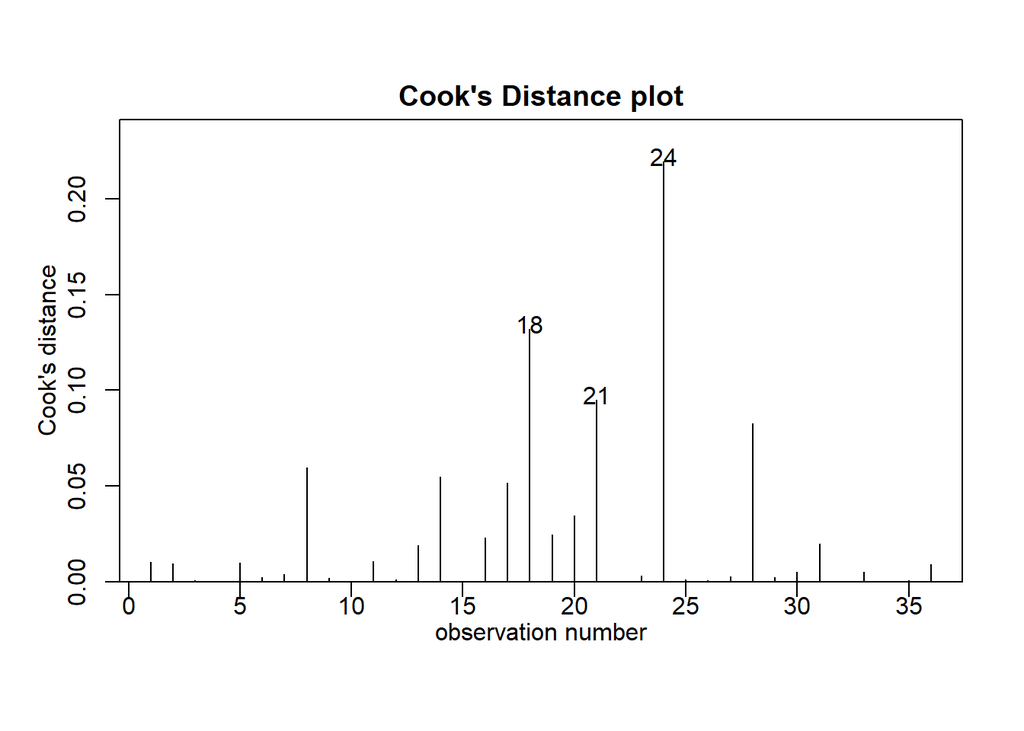

```r
library(s20x)
cooks20x(quad.lm)
```

```r
cooks_values <- cooks.distance(quad.lm)
max_cooks_index <- which.max(cooks_values)


quad2.df <- spruce.df[-max_cooks_index, ]

quad2.lm <- lm(Height ~ BHDiameter + I(BHDiameter^2), data = quad2.df)

summary(quad2.lm)
```

```
##
## Call:
## lm(formula = Height ~ BHDiameter + I(BHDiameter^2), data = quad2.df)
##
## Residuals:
##      Min       1Q   Median       3Q      Max
## -3.11233 -0.48227  0.01253  0.71727  2.59146
##
## Coefficients:
##                  Estimate Std. Error t value Pr(>|t|)
## (Intercept)     -0.341500   2.068479  -0.165     0.87
## BHDiameter       1.564793   0.226102   6.921 7.78e-08 ***
## I(BHDiameter^2) -0.029242   0.006114  -4.782 3.74e-05 ***
## ---
## Signif. codes:  0 '***' 0.001 '**' 0.01 '*' 0.05 '.' 0.1 ' ' 1
##
## Residual standard error: 1.266 on 32 degrees of freedom
## Multiple R-squared:  0.8159, Adjusted R-squared:  0.8044
## F-statistic: 70.91 on 2 and 32 DF,  p-value: 1.74e-12
```

```r
summary(quad.lm)
```

```
##
## Call:
## lm(formula = Height ~ BHDiameter + I(BHDiameter^2), data = spruce.df)
##
## Residuals:
##     Min      1Q  Median      3Q     Max
## -3.2966 -0.6245 -0.0707  0.7442  3.2541
##
## Coefficients:
##                  Estimate Std. Error t value Pr(>|t|)
## (Intercept)      0.860896   2.205022   0.390 0.698731
## BHDiameter       1.469592   0.243786   6.028 8.88e-07 ***
## I(BHDiameter^2) -0.027457   0.006635  -4.138 0.000227 ***
## ---
## Signif. codes:  0 '***' 0.001 '**' 0.01 '*' 0.05 '.' 0.1 ' ' 1
##
## Residual standard error: 1.382 on 33 degrees of freedom
## Multiple R-squared:  0.7741, Adjusted R-squared:  0.7604
## F-statistic: 56.55 on 2 and 33 DF,  p-value: 2.182e-11
```

# Task 7

Proving the Piecewise Model with LaTeX

We want to prove the following model:

$$y = \beta_0 + \beta_1 x + \beta_2 (x - x_k) I(x > x_k)$$

Where $I(x > x_k)$ is an indicator function that equals 1 when $x > x_k$ and 0 otherwise.

### Proof:

$$y = \begin{cases}
\beta_0 + \beta_1 x, & \text{if } x \leq x_k \\
\beta_0 + \beta_1 x + \beta_2 (x - x_k), & \text{if } x > x_k
\end{cases}$$

This can be rewritten using $I(x > x_k)$:

$$y = \beta_0 + \beta_1 x + \beta_2 (x - x_k) I(x > x_k)$$

### Explanation:

1. When $x \leq x_k$, $I(x > x_k) = 0$, simplifying the equation to $y = \beta_0 + \beta_1 x$.
2. When $x > x_k$, $I(x > x_k) = 1$, giving $y = \beta_0 + \beta_1 x + \beta_2 (x - x_k)$.

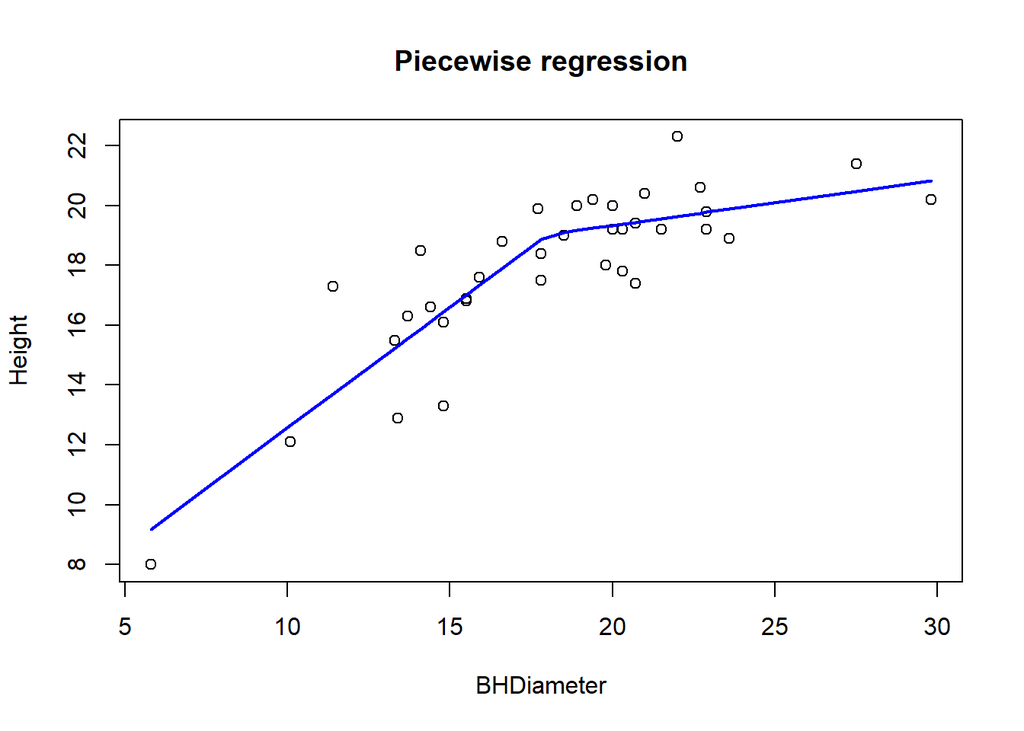

```r
spruce.df$piecewise_term <- pmax(0, spruce.df$BHDiameter - 18)

piecewise.lm <- lm(Height ~ BHDiameter + piecewise_term, data = spruce.df)

plot(spruce.df$BHDiameter, spruce.df$Height, pch = 1, main = "Piecewise regression",
     xlab = "BHDiameter", ylab = "Height")

sorted_indices <- order(spruce.df$BHDiameter)
lines(spruce.df$BHDiameter[sorted_indices], fitted(piecewise.lm)[sorted_indices],
      col = "blue", lwd = 2)
```

# Task 8